# SD-vel osztott Demeaned clustering

Antal Ertl

2023 03 01

### Defining the number of Principal Components to look at

Using the demeaned data, the factor choice is no longer clear at factor = 4 but it is good enough

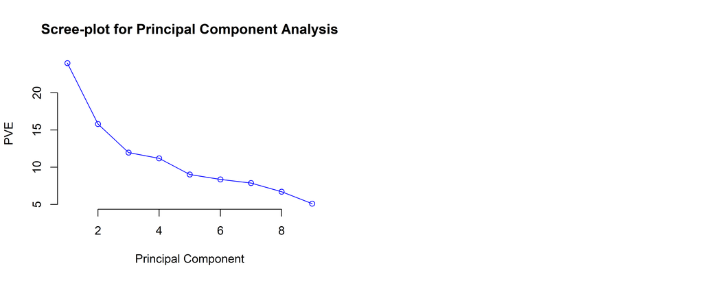

Alternatively, look at the number of Principal Components to attaint using Parallel Analysis.

Parallel Analysis: specify how many components to retain using simulation

Here, we get the critical values for each component. If the eigenvalues from the PCA are greater than the value at 0.95 confint, we can retain given component.

We have two rules: 1) Kaiser’s rule: Eigenvalue has to be >1 (satisfied up to 4 factors, with the 4th being barely above) 2) Eigenvalues being greater than the estimates gathered from Parallel Analysis (Horn, 1965)

```
##
##  Parallel Analysis Results
##
## Method: pca
## Number of variables: 4
## Sample size: 1059
## Number of correlation matrices: 500
## Seed: 1234
## Percentile: 0.95
##
## Compare your observed eigenvalues from your original dataset to the 95 percentile in the table below generated using random data. If your eigenvalue is greater than the percentile indicated (not the mean), you have support to retain that factor/component.
##
##  Component  Mean  0.95
##          1 1.067 1.104
##          2 1.019 1.045
##          3 0.981 1.001
##          4 0.932 0.963
```

```
## Principal Components Analysis
## Call: psych::principal(r = ., nfactors = 4, rotate = "varimax")
## Standardized loadings (pattern matrix) based upon correlation matrix
##                            RC1   RC2   RC3   RC4   h2   u2 com
## delta_diff               -0.04  0.09  0.81  0.22 0.71 0.29 1.2
## beta_diff                 0.06 -0.03 -0.05  0.89 0.80 0.20 1.0
## beta_0_diff              -0.01  0.03 -0.75  0.33 0.67 0.33 1.4
## dictator_diff             0.80  0.05  0.01  0.08 0.65 0.35 1.0
## dictator_schoolmate_diff  0.76  0.02  0.02  0.08 0.58 0.42 1.0
## risk_diff                -0.41  0.69  0.14 -0.03 0.66 0.34 1.7
## publicgood_diff           0.27  0.68 -0.01  0.02 0.54 0.46 1.3
## trust_diff                0.51  0.60 -0.01 -0.13 0.63 0.37 2.1
## trust_return_diff         0.51  0.19 -0.14 -0.34 0.43 0.57 2.2
##
##                        RC1  RC2  RC3  RC4
## SS loadings           1.98 1.34 1.25 1.09
## Proportion Var        0.22 0.15 0.14 0.12
## Cumulative Var        0.22 0.37 0.51 0.63
## Proportion Explained  0.35 0.24 0.22 0.19
## Cumulative Proportion 0.35 0.59 0.81 1.00
##
## Mean item complexity =  1.4
## Test of the hypothesis that 4 components are sufficient.
##
## The root mean square of the residuals (RMSR) is  0.12
##  with the empirical chi square  1034.27  with prob <  3.5e-220
##
## Fit based upon off diagonal values = 0.55
```

Overall, no clear indication on the number of components; still, in order to make it comparable with the non-demeaned data, I calculate with 4 factors in the PCA.

### 3 Factor PCA

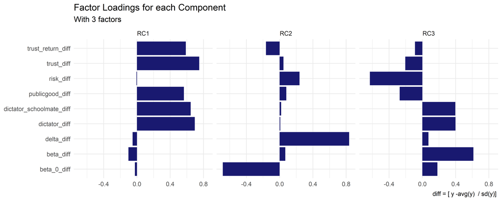

#### 4 Factor PCA

```
##
## Loadings:
##                          RC1    RC2    RC3    RC4
## delta_diff                              0.807  0.222
## beta_diff                                      0.889
## beta_0_diff                            -0.748  0.326
## dictator_diff             0.800
## dictator_schoolmate_diff  0.759
## risk_diff                -0.406  0.690  0.138
## publicgood_diff           0.273  0.679
## trust_diff                0.509  0.595        -0.132
## trust_return_diff         0.510  0.188 -0.136 -0.335
##
##                  RC1   RC2   RC3   RC4
## SS loadings    1.981 1.341 1.252 1.090
## Proportion Var 0.220 0.149 0.139 0.121
## Cumulative Var 0.220 0.369 0.508 0.629
```

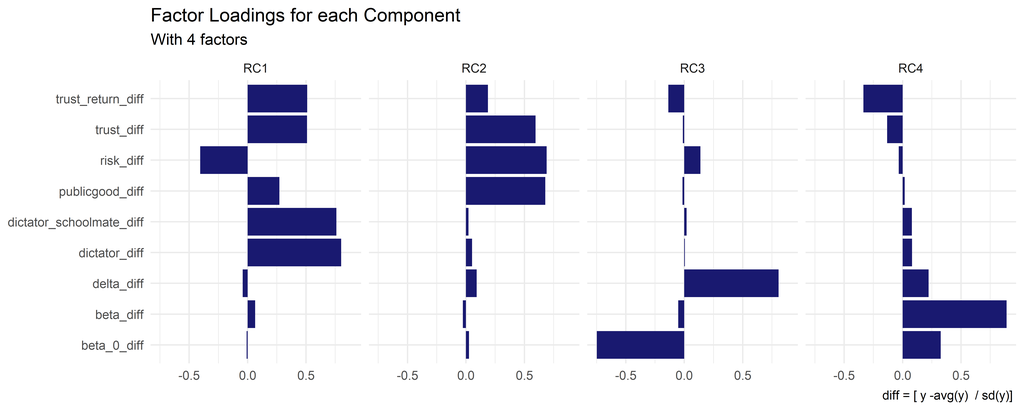

Bottom line: demeaned megmaradtak ugyanazok az eredmények.

A továbbiakban a 4 faktoros PCA-val számoltam. Az elemek elnevezései a következők:

Az ÖSSZES további Random Forest illesztésben a “math” változóra illesztettem a fákat. Lehet még olyat is illeszteni, ahol pl. top 15% percentilisre lövünk.

Random forest math változóra; PCA változók nélkül

[figure not shown]

[figure not shown]

# K-means clustering: [ Egyelőre ez az egyetlen, amit megcsináltam erre ]

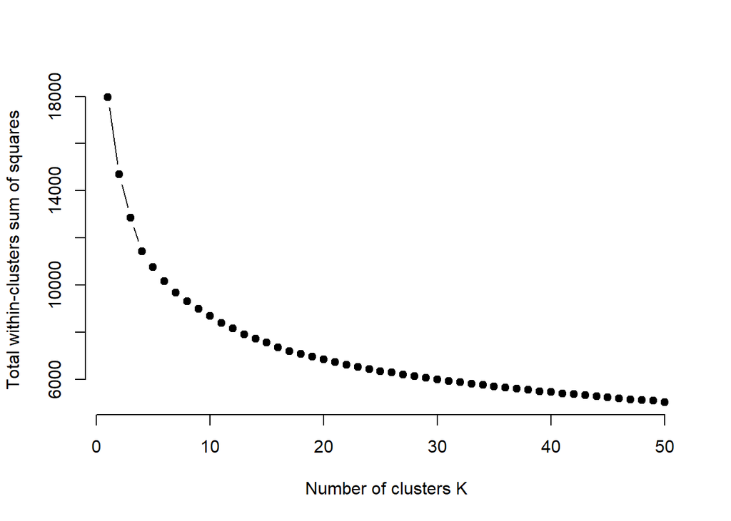

Now knowing that the number of factors is the same, I run the K-means clustering algorithm for 5 clusters:

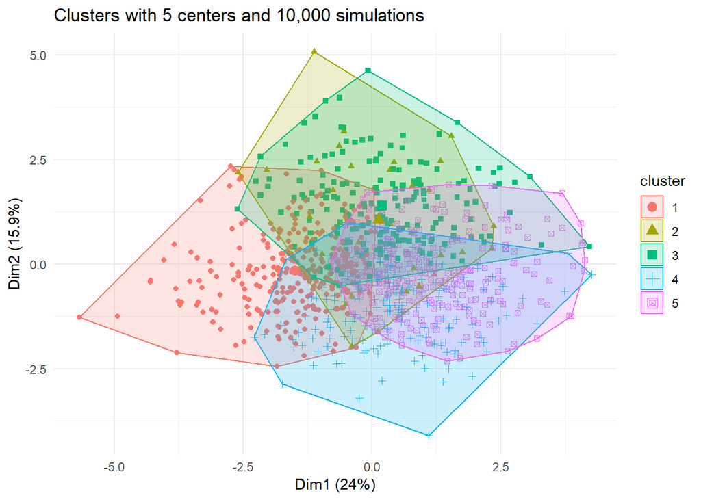